# methDB2_QA

# Basic quality check of MethDB2

Document for a basic quality check of the raw data in the MethDB2, checking mostly the extreme values for now. Also showing the original unit of the data to double check if it is a conversion problem.

Now we can load the files with data, both the concentrations and flux tables have been converted to a common unit (uM and mmol m-2 d-1) for all variables (CH4, CO2, N2O, nutrients)

```r
library(tidyverse)

#Load custom ggplot functions
source("R/ggplot2_utils.R")

# load formatted and converted tables into your R environment
load(file.path(path_to_dropbox, "db_processingR",
               "MethDB_tables_converted.rda"))
```

### Extreme methane values

Let’s plot the distribution of mean CH4 concentration. With vertical lines limiting the top and bottom 10% obrservations

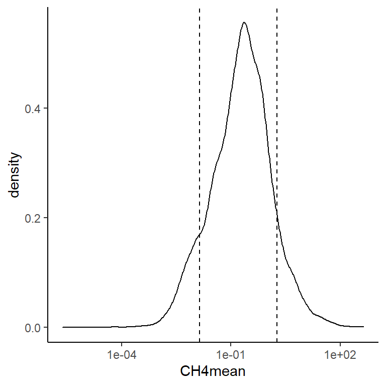

Ok let’s find which sites are the bottom 10%

```
#> # A tibble: 458 x 4
#>     Site_Nid Publication_Nid  CH4mean unit
#>     <chr>              <dbl>    <dbl> <chr>
#>   1 1134                2236 0        ugC/L
#>   2 12549              12530 0        umol/L
#>   3 12555              12530 0        umol/L
#>   4 12556              12530 0        umol/L
#>   5 12557              12530 0        umol/L
#>   6 12558              12530 0        umol/L
#>   7 12559              12530 0        umol/L
#>   8 12560              12530 0        umol/L
#>   9 12561              12530 0        umol/L
#>  10 12562              12530 0        umol/L
#>  11 7444                7197 0        umol/L
#>  12 7456                7245 0        umol/L
```

[output cut: 446 more lines]

And in which papers are those sites:

```
#> # A tibble: 56 x 3
#>    Publication_Nid CH4mean unit
#>              <dbl>   <dbl> <chr>
#>  1            2236 0       ugC/L
#>  2            7197 0       umol/L
#>  3           12530 0       umol/L
#>  4            7213 0.0012  umol/L
#>  5            7248 0.00156 ppm CH4
#>  6            7259 0.00228 uatm CH4
#>  7           11307 0.00295 uatm CH4
#>  8            7202 0.00326 nmol/L
#>  9           12362 0.00349 umol/L
#> 10            7269 0.004   umol/L
#> 11           11604 0.00420 uatm CH4
#> 12            7150 0.00427 nmol/L
```

[output cut: 44 more lines]

Now let’s find which sites are the top 10%

```
#> # A tibble: 567 x 4
#>     Site_Nid Publication_Nid CH4mean unit
#>     <chr>              <dbl>   <dbl> <chr>
#>   1 3452                2279  399.   ugC/L
#>   2 11594              12435  171.   ugC/L
#>   3 1772                7256  146.   umol/L
#>   4 6099                7192  118.   umol/L
#>   5 1771                7256  117.   umol/L
#>   6 1404                2308  109.   uatm CH4
#>   7 7329                7147   88.5  nmol/L
#>   8 3374                2279   81.4  ugC/L
#>   9 7668                7259   79.4  umol/L
#>  10 3380                2279   77.9  ugC/L
#>  11 2051                2292   76.4  umol/L
#>  12 8409                7263   71.4  nmol/L
```

[output cut: 555 more lines]

And in which papers, sorted from high to low:

```
#> # A tibble: 104 x 3
#>     Publication_Nid CH4mean unit
#>               <dbl>   <dbl> <chr>
#>   1           12435  161.   ugC/L
#>   2            2223   70.2  umol/L
#>   3            7147   57.3  nmol/L
#>   4            2292   49.4  umol/L
#>   5            2308   41.2  uatm CH4
#>   6            7210   24    umol/L
#>   7            2222   18.2  mgC/L
#>   8           11721   17.1  mgCH4/L
#>   9           12349   15.3  umol/L
#>  10            2225   15.0  nmol/L
#>  11           12680   14.3  mgCH4/L
#>  12            7241   13.7  nmol/L
```

[output cut: 92 more lines]

### Extreme carbon dioxide values

For the other gasses, given that the number of sites is huge, we relax the limit to top/bottom 5%.

Let’s plot the distribution of mean CO2 concentration. With vertical lines limiting the top and bottom 5% observations

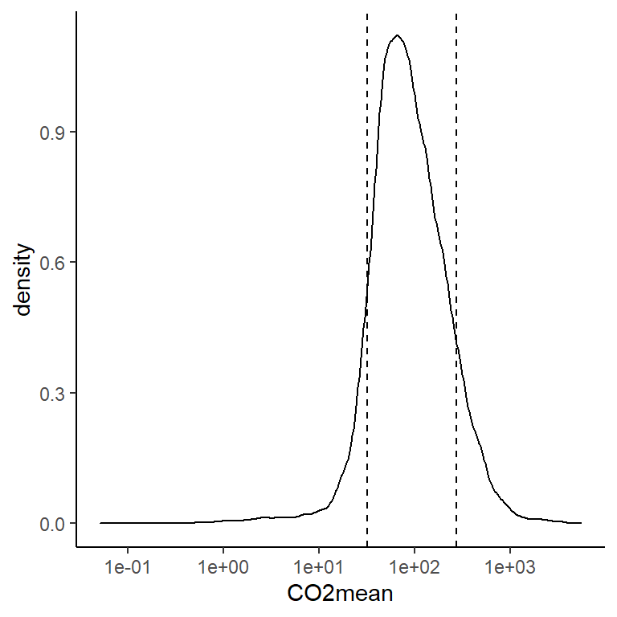

Ok let’s find which sites are the bottom 5%

```
#> # A tibble: 277 x 4
#>     Site_Nid Publication_Nid CO2mean unit
#>     <chr>              <dbl>   <dbl> <chr>
#>   1 2561                2319  0.0512 umol/L
#>   2 1189                2243  0.399  ppm CO2
#>   3 12066              12064  0.797  ppm CO2
#>   4 6080                7192  1.11   umol/L
#>   5 11728              11727  1.19   uatm CO2
#>   6 12085              12064  1.29   ppm CO2
#>   7 3114                7160  1.67   mgC/L
#>   8 8490                7263  2.02   ppm CO2
#>   9 8455                7263  2.06   ppm CO2
#>  10 8456                7263  2.71   ppm CO2
#>  11 8487                7263  2.89   ppm CO2
#>  12 8476                7263  2.90   ppm CO2
```

[output cut: 265 more lines]

And in which papers are those sites:

```
#> # A tibble: 47 x 3
#>    Publication_Nid CO2mean unit
#>              <dbl>   <dbl> <chr>
#>  1           11727    1.19 uatm CO2
#>  2            7160    1.67 mgC/L
#>  3           12064    3.96 ppm CO2
#>  4            2299    6.65 umol/L
#>  5            7242    8.43 ppm CO2
#>  6            2228    9.08 umol/L
#>  7            7244    9.63 umol/L
#>  8            7263    9.63 ppm CO2
#>  9            7259    9.94 uatm CO2
#> 10            7192   10.6  umol/L
#> 11            7245   11.3  umol/L
#> 12            2237   12.1  umol/L
```

[output cut: 35 more lines]

Now let’s find which sites are the top 5%

```
#> # A tibble: 261 x 4
#>     Site_Nid Publication_Nid CO2mean unit
#>     <chr>              <dbl>   <dbl> <chr>
#>   1 2523                2310   3463. ugCO2/L
#>   2 2524                2310   2435. ugCO2/L
#>   3 2518                2310   2209. ugCO2/L
#>   4 3226                2279   2150. mgC/L
#>   5 2513                2310   1974. ugCO2/L
#>   6 3452                2279   1894. mgC/L
#>   7 2423                2302   1689. mgC/L
#>   8 12069              12032   1551. umol/L
#>   9 1607                2259   1548. umol/L
#>  10 7585                7225   1448. umol/L
#>  11 3233                2279   1385. mgC/L
#>  12 2530                2310   1370. ugCO2/L
```

[output cut: 249 more lines]

And in which papers:

```
#> # A tibble: 56 x 3
#>    Publication_Nid CO2mean unit
#>              <dbl>   <dbl> <chr>
#>  1            7264   1167. umol/L
#>  2            2259   1144  umol/L
#>  3           12435   1091. mgC/L
#>  4            2310   1027. ugCO2/L
#>  5            2305   1004. ppm CO2
#>  6            2279    958. mgC/L
#>  7            2297    817. umol/L
#>  8            2302    814. mgC/L
#>  9            7225    792. umol/L
#> 10           12032    789. umol/L
#> 11            2289    780. umol/L
#> 12            2240    766. umol/L
```

[output cut: 44 more lines]

### Extreme nitrous oxide values

Let’s plot the distribution of mean N2O concentration. With vertical lines limiting the top and bottom 5% observations

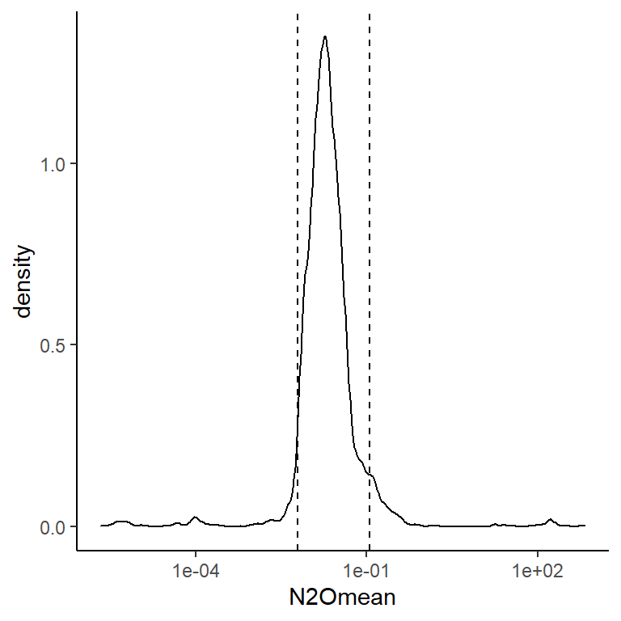

Ok let’s find which sites are the bottom 5%

```
#> # A tibble: 148 x 4
#>     Site_Nid Publication_Nid    N2Omean unit
#>     <chr>              <dbl>      <dbl> <chr>
#>   1 1090                2228 0          umol/L
#>   2 11721              11721 0          ugN2O/L
#>   3 12033              12032 0          umol/L
#>   4 12034              12032 0          umol/L
#>   5 12035              12032 0          umol/L
#>   6 12036              12032 0          umol/L
#>   7 12037              12032 0          umol/L
#>   8 12038              12032 0          umol/L
#>   9 12039              12032 0          umol/L
#>  10 12040              12032 0          umol/L
#>  11 12041              12032 0          umol/L
#>  12 12042              12032 0          umol/L
```

[output cut: 136 more lines]

And in which papers are those sites:

```
#> # A tibble: 23 x 3
#>    Publication_Nid   N2Omean unit
#>              <dbl>     <dbl> <chr>
#>  1            2228 0         umol/L
#>  2           12032 0         umol/L
#>  3           12680 0         ugN2O/L
#>  4           12840 0.0000465 nmol/L
#>  5            7223 0.0001    umol/L
#>  6            2289 0.000951  nmol/L
#>  7           11721 0.00141   ugN2O/L
#>  8            7256 0.00305   nmol/L
#>  9            7263 0.00414   nmol/L
#> 10            2309 0.00420   umol/L
#> 11           12064 0.00421   ppm N2O
#> 12           11604 0.00443   uatm N2O
#> 13            7241 0.00490   nmol/L
#> 14            2277 0.00493   nmol/L
#> 15            2311 0.00505   nmol/L
#> 16            7225 0.00553   nmol/L
#> 17            2297 0.00570   umol/L
#> 18            2264 0.006     nmol/L
#> 19            7147 0.006     nmol/L
#> 20            7227 0.006     nmol/L
#> 21            2276 0.00610   nmol/L
#> 22            7235 0.00610   nmol/L
#> 23            2303 0.00612   umol/L
```

```
#> # A tibble: 111 x 4
#>     Site_Nid Publication_Nid N2Omean unit
#>     <chr>              <dbl>   <dbl> <chr>
#>   1 1631               12457 666.    mgN/L
#>   2 1630               12457 515.    mgN/L
#>   3 1629               12457 333.    mgN/L
#>   4 1628               12457 296.    mgN/L
#>   5 1627               12457 174.    mgN/L
#>   6 12655              12484 166.    umol/L
#>   7 1626               12457 159.    mgN/L
#>   8 1625               12457 144.    mgN/L
#>   9 1624               12457 121.    mgN/L
#>  10 1622               12457 114.    mgN/L
#>  11 1623               12457  98.5   mgN/L
#>  12 1632               12457  77.1   mgN/L
```

[output cut: 99 more lines]

And in which papers:

```
#> # A tibble: 27 x 3
#>    Publication_Nid N2Omean unit
#>              <dbl>   <dbl> <chr>
#>  1           12484 166.    umol/L
#>  2           12457 120.    mgN/L
#>  3            2280   1.5   umol/L
#>  4            2309   0.558 umol/L
#>  5            2259   0.536 nmol/L
#>  6            7215   0.366 nmol/L
#>  7            2304   0.342 umol/L
#>  8            2303   0.296 umol/L
#>  9            2310   0.291 ugN2O/L
#> 10           12258   0.266 nmol/L
#> 11            2255   0.254 ugN2O/L
#> 12           11744   0.232 umol/L
#> 13           11721   0.228 ugN2O/L
#> 14            2288   0.222 nmol/L
#> 15            7170   0.216 umol/L
#> 16            7225   0.215 nmol/L
#> 17           11306   0.198 nmol/L
#> 18            7227   0.196 nmol/L
#> 19            2235   0.172 ugN/L
#> 20            2228   0.160 umol/L
#> 21            2301   0.152 ugN2O/L
#> 22            2271   0.146 ugN/L
#> 23           12680   0.135 ugN2O/L
#> 24            2275   0.133 nmol/L
#> 25            2277   0.129 nmol/L
#> 26           12840   0.128 umol/L
#> 27            2269   0.121 ugN/L
```